# Week 04 Problem Set: Data wrangling & transformation

Sami Cemek

## Some notes on dplyr

Check out the “DataTransformationSupplement” for information on

- Workflow with dplyr (saving vs printing)
- Renaming variables
- Recoding categorical variables
- Turning quantitative variables into categorical variables using mutate() and case_when().

#### Some trouble-shooting tips:

- These functions assume you are working with a tidy data frame. That is, each column represents one variable, and each row represents one case.
- You may run into issues because other packages have similarly named functions (there are several functions called `select()`, for example). If R gives you trouble about recognizing the function name, you can explicitly refer to the function within `dplyr` using `::`. For example, `dplyr::select(my_data, var1)` tells R to use the `select()` function in `dplyr`.
- **Remember to save your data set if you modify it!** If you filter or mutate without saving the data set, it will print out the results (all 4500 rows) but will not save the data for you to use. You will lose points if you accidentally print out the data set rather than saving it or only printing specified rows.
  - Pro tip: Open your knitted html file and read it through BEFORE you submit the assignment.

# Exercise 1

The data set `chicago`, which we imported in the set-up chunk, contains variables measuring air pollution and weather in Chicago.

- “city”: the city abbreviation
- “tmpd”: temperature (degress F)
- “dptp”: Dewpoint
- “date”: the date, ranging from Jan 1, 1987 to Dec 31, 2005
- “pm25tmean2”: a common pollution measure of fine particles. PM2.5 refers to the average concentration of atmospheric particulate matter that have a diameter of less than 2.5 micrometers; measured in micrograms per cubic meter
- “pm10tmean2”: another pollution measure, referring to the average concentration of atmospheric particulate matter with a diameter of less than 10 micrometers; measured in micrograms per cubic meter
- “o3tmean2”: ground level ozone (not sure of units?)
- “no2tmean2”: nitrogen dioxide (not sure of units?)

## Part a.

1. Suppose we want to focus on the pollution variables (pm25tmean2, pm10tmean2, o3tmean2, and no2tmean2). Show at least two ways to keep only these columns in the data frame, while omitting the other columns. Print out the first three rows of the new data frame.

**Hint:** For the second way, look through the help file for `starts_with()` and `ends_with()`. These are useful, when combined with `select()`!

**Your answer:**

```r
#1
pollutionVars <- chicago %>%
  dplyr::select(pm25tmean2,pm10tmean2,o3tmean2,no2tmean2)
  head(pollutionVars,3)
```

```
##   pm25tmean2 pm10tmean2 o3tmean2 no2tmean2
## 1         NA   34.00000 4.250000  19.98810
## 2         NA         NA 3.304348  23.19099
## 3         NA   34.16667 3.333333  23.81548
```

```r
#2
pollutionVars2 <- chicago %>%
  dplyr::select(-city,-tmpd,-dptp,-date)
  head(pollutionVars2,3)
```

```
##   pm25tmean2 pm10tmean2 o3tmean2 no2tmean2
## 1         NA   34.00000 4.250000  19.98810
## 2         NA         NA 3.304348  23.19099
## 3         NA   34.16667 3.333333  23.81548
```

## Part b.

2. Go back to the main data set (not the data set you created in part a. The variable names are unclear and complicated. Rename the following variables, and save the results in a new `chicago2` data frame.

You will use this `chicago2` data for the remaining exercises in the problem set, though you may modify it further in future exercises.

- “tmpd”: temp
- “dptp”: dewpt
- “pm25tmean2”: pm25
- “pm10tmean2”: pm10
- “o3tmean2”: ozone
- “no2tmean2”: no2

**Your answer:**

```r
chicago2 <- chicago %>%
  rename(temp = tmpd,dewpt = dptp, pm25 = pm25tmean2, pm10 = pm10tmean2, ozone = o3tmean2, no2 = no2tmean2)
str(chicago2)
```

```
## 'data.frame':    6940 obs. of  8 variables:
##  $ city : chr  "chic" "chic" "chic" "chic" ...
##  $ temp : num  31.5 33 33 29 32 40 34.5 29 26.5 32.5 ...
##  $ dewpt: num  31.5 29.9 27.4 28.6 28.9 ...
##  $ date : Date, format: "1987-01-01" "1987-01-02" ...
##  $ pm25 : num  NA NA NA NA NA NA NA NA NA NA ...
##  $ pm10 : num  34 NA 34.2 47 NA ...
##  $ ozone: num  4.25 3.3 3.33 4.38 4.75 ...
##  $ no2  : num  20 23.2 23.8 30.4 30.3 ...
```

## Part c.

3. Print out the dates, pm2.5 values, and ozone values only for the **five** days with the highest pm2.5 concentration levels. The data should be sorted first by pm2.5 level and then by ozone level (highest values first).

**Your answer:**

```r
chicago2 %>%
  select(pm25, ozone, date) %>%
  top_n(n = 5, wt = pm25) %>%
  group_by(pm25) %>%
  arrange(desc(pm25), desc(ozone))
```

```
## # A tibble: 5 x 3
## # Groups:   pm25 [4]
##    pm25 ozone date
##   <dbl> <dbl> <date>
## 1  61.5  4.81 2005-02-04
## 2  56.5 51.7  2005-09-11
## 3  56.5 38.6  1998-05-15
## 4  52    6.24 2005-02-02
## 5  51.5 55.2  2005-06-27
```

## Part d.

4. On how many days were the pm2.5 concentration greater than 35 and the ozone level greater than 18? (Don’t print out the data set– just the number of days in the data set where this is true. Your answer should be a single number.)

**Your answer:** The answer is 44 but couldn’t figure out how to print the number directly.

```r
chicago2 %>%
  filter(pm25 > 35 & ozone > 18)
```

```
##    city temp dewpt       date     pm25     pm10    ozone      no2
## 1  chic   75  65.8 1998-05-15 56.50000 91.00000 38.57301 29.03261
## 2  chic   78  67.1 1998-07-14 41.40000 75.00000 40.08090 32.59054
## 3  chic   78  64.8 1998-08-03 36.40000 61.53846 34.80221 24.71528
## 4  chic   81  71.2 1998-08-23 39.60000 59.00000 45.86364 14.32639
## 5  chic   60  54.8 1999-05-15 45.60000 45.50000 22.42424 23.55556
## 6  chic   75  68.2 1999-06-12 36.00000 39.50000 39.67803 30.95833
## 7  chic   76  67.3 1999-06-23 49.04286 57.57143 45.56603 27.47288
## 8  chic   80  69.7 1999-08-28 39.54000 56.57143 31.51250 30.65000
## 9  chic   76  61.5 1999-09-03 44.95714 74.00000 48.11656 42.98279
## 10 chic   51  42.5 2000-04-02 40.30000 46.00000 21.67130 25.92500
## 11 chic   77  70.6 2000-08-30 41.70000 59.00000 29.67885 19.30299
## 12 chic   68  58.3 2000-10-26 41.40000 65.50000 18.04538 32.05543
## 13 chic   42  33.4 2001-03-22 36.05000 39.00000 18.15278 41.73991
## 14 chic   42  31.9 2001-03-30 40.30000 49.00000 26.56944 28.30556
```

[output cut: 30 more lines]

```r
#sum(isTRUE(chicago2$pm25 > 35 && chicago2$ozone > 18))
#nrow((question1D$pm25 > 35 & question1D$ozone > 18))

sum((chicago2$pm25 > 35 ) && (chicago2$ozone > 18))
```

```
## [1] 0
```

```r
#sum(TRUE == (pm25 > 35 & ozone > 18))
#count(isTRUE(pm25 > 35 & ozone > 18))

#nrow((chicago2$pm25 > 35))
```

## Part e.

5. For how many days is the pm2.5 variable missing? Print the number of days for which this variable is missing. Your answer should be a single number.

Intermediate challenge: In addition to the number of days with missing pm2.5 data, on those days when pm2.5 is missing, what other variables tend to be missing as well? That is, if you focus only on days with no pm2.5 reading, how many of those days are also missing other variables, such as temperature, ozone, or pm10? Try to find a way to solve this that does not involve manually viewing the data and counting the days for each variable.

**Your answer:**

```r
sum(is.na(chicago2$pm25))
```

```
## [1] 4447
```

## Part f.

6. Create a new variable, tempC, that measures the temperature in celsius. Recall that to convert a Fahrenheit temperature to Celsius, you need to deduct 32, then multiply by 5, then divide by 9.

Make sure you will be able to use this variable again in the future with your data, by saving the new data set as chicagoC. Print out the first 4 rows of the Fahrenheit and Celsius temperatures only (not the other variables).

**Your answer:**

```r
#tempC <- ((chicago2$temp - 32) * 5/9)
chicagoC <- chicago2 %>%
  mutate(tempC = ((temp - 32) * 5/9)) %>%
  select(temp, tempC)
head(chicagoC, 4)
```

```
##   temp      tempC
## 1 31.5 -0.2777778
## 2 33.0  0.5555556
## 3 33.0  0.5555556
## 4 29.0 -1.6666667
```

# Exercise 2

Continue working with the chicago2 data. Now we will step beyond the functions covered this week to see how they can be strengthened even more when combined with some other common functions in R.

## Part a.

1. Install the `lubridate` package in your console if needed, then load the package. Using the `year()` and `month()` functions to create new variables showing just the year and month, respectively.

Hint: If you have a column of dates called DATES, then you can find the year for each date by using `year(DATES)`.

**Your answer:**

```r
#install.packages("lubridate")
#library(lubridate)

yearVar<- chicago2 %>%
  mutate(date = year(chicago2$date)) %>%
  group_by(date)

#yearVar <- year(chicago2$date)
#yearMonthVar <- (year(chicago2$date),month(chicago2$date))
```

## Part b.

2. Use mutate() and case_when() to create a categorical variable based on temperature. Call this variable “temp_cat”. Again, make sure you will be able to use this variable in the future in the chicago2 data set.
- hot: temp > 90
- warm: temp > 70 and <= 90
- cool: temp > 50 and <=70
- cold: temp > 32 and <= 50
- freezing: temp <= 32

Hint: The week 03 problem set included an example of how to create a budget category variable similar to this. Check the setup code chunk in that assignment for more details, or check the “DataTransformationSupplement.html” file in this assignment folder.

**Your answer:**

```r
chicago3 <- chicago2 %>%
  mutate(temp_cat = case_when(
    temp > 90 ~ "hot",
    temp > 70 & temp <= 90 ~ "warm",
    temp > 50 & temp <= 70 ~ "cool",
    temp > 32 & temp <= 50 ~ "cold",
    temp <= 32 ~ "freezing"))
```

## Part c.

3. Use the data from the previous two steps to create a scatterplot of ozone and pm2.5, with a different color for each temperature category, faceted by year.

**Your answer:**

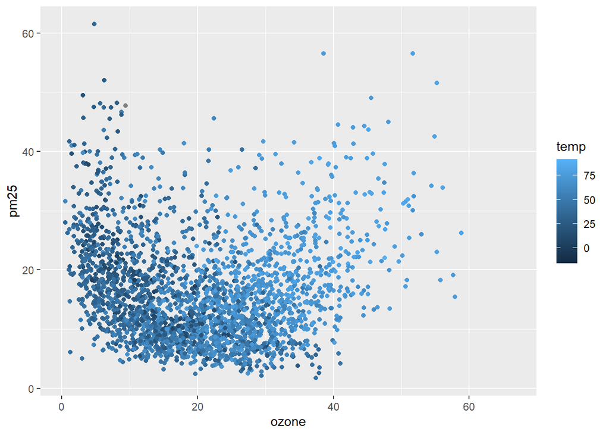

```r
#chicago %>%
#group_by(yearVar) %>%
ggplot(chicago2, aes(x=ozone, y= pm25, color=temp))+
  geom_point()
```

```r
#+ facet_wrap(~ yearVar)
```

# Exercise 3: Intermediate

Intermediate students should also complete this problem in addition to the first two exercises. It is optional for introductory students.

Continue working with the chicago2 data you created in the previous question. At this point, you should have:

- Renamed the variables to temp, dewpt, pm25, pm10, ozone, and n02.
- Created year and month variables using lubridate.
- Created the temperature category variable.
- Saved the results in a new data frame called “chicago2”

## Part a.

1. Verify that there are 12 months listed for each year in the data set. In other words, double check that there is not a year when, for example, November or January were excluded.

**Your answer:**

## Part b.

2. Find the average pm2.5 count per year, for each year in the data set. It’s good practice to also list the number of days each year for which the pm2.5 value was missing, and the number of days for which it was measured.

To answer this question, create a summary table in which each row is a year and there are columns showing the year, average pm 2.5, number of non-missing pm 2.5 observations for that year, and number of missing pm 2.5 measurements for that year.

**Your answer:**

## Part c.

3. Try to find the percent of days in each year with pm2.5 > 30. (You should have a separate percentage for each year in the data set)

**Your answer:**

## Part d.

4. Recreate a scatterplot of pm2.5 (y) vs ozone (x), with the points on warmer days (temperature >= 80) colored red and all the other points colored grey. Comment on what the graph shows, if anything, about how temperature is related to ozone and pm2.5.

**Your answer:**